# 📌 Extracción

> ✅ Cargar los datos directamente desde la API utilizando Python.

> ✅ Convertir los datos a un DataFrame de Pandas para facilitar su manipulación.

```python
import pandas as pd
import numpy as np
import matplotlib.pyplot as plt
import plotly.express as px

import requests
import io
```

```python
# Cargamos nuestro Github en una variable
url = 'https://raw.githubusercontent.com/WMRioga/Challenge_02_TelecomX/refs/heads/main/TelecomX_Data.json'

# Validamos nuestro documento json solo por comprobación
df = pd.read_json('./TelecomX_Data.json')
df
```

|  | customerID | Churn | customer | phone | internet | account |
| --- | --- | --- | --- | --- | --- | --- |
| 0 | 0002-ORFBO | No | {'gender': 'Female', 'SeniorCitizen': 0, 'Part... | {'PhoneService': 'Yes', 'MultipleLines': 'No'} | {'InternetService': 'DSL', 'OnlineSecurity': '... | {'Contract': 'One year', 'PaperlessBilling': '... |
| 1 | 0003-MKNFE | No | {'gender': 'Male', 'SeniorCitizen': 0, 'Partne... | {'PhoneService': 'Yes', 'MultipleLines': 'Yes'} | {'InternetService': 'DSL', 'OnlineSecurity': '... | {'Contract': 'Month-to-month', 'PaperlessBilli... |
| 2 | 0004-TLHLJ | Yes | {'gender': 'Male', 'SeniorCitizen': 0, 'Partne... | {'PhoneService': 'Yes', 'MultipleLines': 'No'} | {'InternetService': 'Fiber optic', 'OnlineSecu... | {'Contract': 'Month-to-month', 'PaperlessBilli... |
| 3 | 0011-IGKFF | Yes | {'gender': 'Male', 'SeniorCitizen': 1, 'Partne... | {'PhoneService': 'Yes', 'MultipleLines': 'No'} | {'InternetService': 'Fiber optic', 'OnlineSecu... | {'Contract': 'Month-to-month', 'PaperlessBilli... |
| 4 | 0013-EXCHZ | Yes | {'gender': 'Female', 'SeniorCitizen': 1, 'Part... | {'PhoneService': 'Yes', 'MultipleLines': 'No'} | {'InternetService': 'Fiber optic', 'OnlineSecu... | {'Contract': 'Month-to-month', 'PaperlessBilli... |
| ... | ... | ... | ... | ... | ... | ... |
| 7262 | 9987-LUTYD | No | {'gender': 'Female', 'SeniorCitizen': 0, 'Part... | {'PhoneService': 'Yes', 'MultipleLines': 'No'} | {'InternetService': 'DSL', 'OnlineSecurity': '... | {'Contract': 'One year', 'PaperlessBilling': '... |
| 7263 | 9992-RRAMN | Yes | {'gender': 'Male', 'SeniorCitizen': 0, 'Partne... | {'PhoneService': 'Yes', 'MultipleLines': 'Yes'} | {'InternetService': 'Fiber optic', 'OnlineSecu... | {'Contract': 'Month-to-month', 'PaperlessBilli... |
| 7264 | 9992-UJOEL | No | {'gender': 'Male', 'SeniorCitizen': 0, 'Partne... | {'PhoneService': 'Yes', 'MultipleLines': 'No'} | {'InternetService': 'DSL', 'OnlineSecurity': '... | {'Contract': 'Month-to-month', 'PaperlessBilli... |
| 7265 | 9993-LHIEB | No | {'gender': 'Male', 'SeniorCitizen': 0, 'Partne... | {'PhoneService': 'Yes', 'MultipleLines': 'No'} | {'InternetService': 'DSL', 'OnlineSecurity': '... | {'Contract': 'Two year', 'PaperlessBilling': '... |
| 7266 | 9995-HOTOH | No | {'gender': 'Male', 'SeniorCitizen': 0, 'Partne... | {'PhoneService': 'No', 'MultipleLines': 'No ph... | {'InternetService': 'DSL', 'OnlineSecurity': '... | {'Contract': 'Two year', 'PaperlessBilling': '... |

7267 rows × 6 columns

```python
# Descargamos el contenido de la URL directamente desde la nube para trabajar con el
response = requests.get(url)
content = response.content
df = pd.read_json(io.StringIO(content.decode('utf-8')))
df
```

|  | customerID | Churn | customer | phone | internet | account |
| --- | --- | --- | --- | --- | --- | --- |
| 0 | 0002-ORFBO | No | {'gender': 'Female', 'SeniorCitizen': 0, 'Part... | {'PhoneService': 'Yes', 'MultipleLines': 'No'} | {'InternetService': 'DSL', 'OnlineSecurity': '... | {'Contract': 'One year', 'PaperlessBilling': '... |
| 1 | 0003-MKNFE | No | {'gender': 'Male', 'SeniorCitizen': 0, 'Partne... | {'PhoneService': 'Yes', 'MultipleLines': 'Yes'} | {'InternetService': 'DSL', 'OnlineSecurity': '... | {'Contract': 'Month-to-month', 'PaperlessBilli... |
| 2 | 0004-TLHLJ | Yes | {'gender': 'Male', 'SeniorCitizen': 0, 'Partne... | {'PhoneService': 'Yes', 'MultipleLines': 'No'} | {'InternetService': 'Fiber optic', 'OnlineSecu... | {'Contract': 'Month-to-month', 'PaperlessBilli... |
| 3 | 0011-IGKFF | Yes | {'gender': 'Male', 'SeniorCitizen': 1, 'Partne... | {'PhoneService': 'Yes', 'MultipleLines': 'No'} | {'InternetService': 'Fiber optic', 'OnlineSecu... | {'Contract': 'Month-to-month', 'PaperlessBilli... |
| 4 | 0013-EXCHZ | Yes | {'gender': 'Female', 'SeniorCitizen': 1, 'Part... | {'PhoneService': 'Yes', 'MultipleLines': 'No'} | {'InternetService': 'Fiber optic', 'OnlineSecu... | {'Contract': 'Month-to-month', 'PaperlessBilli... |
| ... | ... | ... | ... | ... | ... | ... |
| 7262 | 9987-LUTYD | No | {'gender': 'Female', 'SeniorCitizen': 0, 'Part... | {'PhoneService': 'Yes', 'MultipleLines': 'No'} | {'InternetService': 'DSL', 'OnlineSecurity': '... | {'Contract': 'One year', 'PaperlessBilling': '... |
| 7263 | 9992-RRAMN | Yes | {'gender': 'Male', 'SeniorCitizen': 0, 'Partne... | {'PhoneService': 'Yes', 'MultipleLines': 'Yes'} | {'InternetService': 'Fiber optic', 'OnlineSecu... | {'Contract': 'Month-to-month', 'PaperlessBilli... |
| 7264 | 9992-UJOEL | No | {'gender': 'Male', 'SeniorCitizen': 0, 'Partne... | {'PhoneService': 'Yes', 'MultipleLines': 'No'} | {'InternetService': 'DSL', 'OnlineSecurity': '... | {'Contract': 'Month-to-month', 'PaperlessBilli... |
| 7265 | 9993-LHIEB | No | {'gender': 'Male', 'SeniorCitizen': 0, 'Partne... | {'PhoneService': 'Yes', 'MultipleLines': 'No'} | {'InternetService': 'DSL', 'OnlineSecurity': '... | {'Contract': 'Two year', 'PaperlessBilling': '... |
| 7266 | 9995-HOTOH | No | {'gender': 'Male', 'SeniorCitizen': 0, 'Partne... | {'PhoneService': 'No', 'MultipleLines': 'No ph... | {'InternetService': 'DSL', 'OnlineSecurity': '... | {'Contract': 'Two year', 'PaperlessBilling': '... |

7267 rows × 6 columns

# 🔧 Transformación

✅ Explorar las columnas del dataset y verificar sus tipos de datos.

✅ Consultar el diccionario para comprender mejor el significado de las variables.

✅ Identificar las columnas más relevantes para el análisis de evasión.

```python
# Validamos columnas
df.columns
```

```
Index(['customerID', 'Churn', 'customer', 'phone', 'internet', 'account'], dtype='object')
```

```python
df.info()
```

```
<class 'pandas.core.frame.DataFrame'>
RangeIndex: 7267 entries, 0 to 7266
Data columns (total 6 columns):
 #   Column      Non-Null Count  Dtype
---  ------      --------------  -----
 0   customerID  7267 non-null   object
 1   Churn       7267 non-null   object
 2   customer    7267 non-null   object
 3   phone       7267 non-null   object
 4   internet    7267 non-null   object
 5   account     7267 non-null   object
dtypes: object(6)
memory usage: 340.8+ KB
```

✅ Identificar las columnas para la normaliizacion de la base de datos.

```python
# Separamos las columnas que no vamos normalizar
columnas_01 = df[['customerID','Churn']]
columnas_01
```

|  | customerID | Churn |
| --- | --- | --- |
| 0 | 0002-ORFBO | No |
| 1 | 0003-MKNFE | No |
| 2 | 0004-TLHLJ | Yes |
| 3 | 0011-IGKFF | Yes |
| 4 | 0013-EXCHZ | Yes |
| ... | ... | ... |
| 7262 | 9987-LUTYD | No |
| 7263 | 9992-RRAMN | Yes |
| 7264 | 9992-UJOEL | No |
| 7265 | 9993-LHIEB | No |
| 7266 | 9995-HOTOH | No |

7267 rows × 2 columns

```python
# Tomamos las columnas que si vamos a normalizar del json
columnas_02 =df[['customer', 'phone', 'internet', 'account']]
columnas_02
```

|  | customer | phone | internet | account |
| --- | --- | --- | --- | --- |
| 0 | {'gender': 'Female', 'SeniorCitizen': 0, 'Part... | {'PhoneService': 'Yes', 'MultipleLines': 'No'} | {'InternetService': 'DSL', 'OnlineSecurity': '... | {'Contract': 'One year', 'PaperlessBilling': '... |
| 1 | {'gender': 'Male', 'SeniorCitizen': 0, 'Partne... | {'PhoneService': 'Yes', 'MultipleLines': 'Yes'} | {'InternetService': 'DSL', 'OnlineSecurity': '... | {'Contract': 'Month-to-month', 'PaperlessBilli... |
| 2 | {'gender': 'Male', 'SeniorCitizen': 0, 'Partne... | {'PhoneService': 'Yes', 'MultipleLines': 'No'} | {'InternetService': 'Fiber optic', 'OnlineSecu... | {'Contract': 'Month-to-month', 'PaperlessBilli... |
| 3 | {'gender': 'Male', 'SeniorCitizen': 1, 'Partne... | {'PhoneService': 'Yes', 'MultipleLines': 'No'} | {'InternetService': 'Fiber optic', 'OnlineSecu... | {'Contract': 'Month-to-month', 'PaperlessBilli... |
| 4 | {'gender': 'Female', 'SeniorCitizen': 1, 'Part... | {'PhoneService': 'Yes', 'MultipleLines': 'No'} | {'InternetService': 'Fiber optic', 'OnlineSecu... | {'Contract': 'Month-to-month', 'PaperlessBilli... |
| ... | ... | ... | ... | ... |
| 7262 | {'gender': 'Female', 'SeniorCitizen': 0, 'Part... | {'PhoneService': 'Yes', 'MultipleLines': 'No'} | {'InternetService': 'DSL', 'OnlineSecurity': '... | {'Contract': 'One year', 'PaperlessBilling': '... |
| 7263 | {'gender': 'Male', 'SeniorCitizen': 0, 'Partne... | {'PhoneService': 'Yes', 'MultipleLines': 'Yes'} | {'InternetService': 'Fiber optic', 'OnlineSecu... | {'Contract': 'Month-to-month', 'PaperlessBilli... |
| 7264 | {'gender': 'Male', 'SeniorCitizen': 0, 'Partne... | {'PhoneService': 'Yes', 'MultipleLines': 'No'} | {'InternetService': 'DSL', 'OnlineSecurity': '... | {'Contract': 'Month-to-month', 'PaperlessBilli... |
| 7265 | {'gender': 'Male', 'SeniorCitizen': 0, 'Partne... | {'PhoneService': 'Yes', 'MultipleLines': 'No'} | {'InternetService': 'DSL', 'OnlineSecurity': '... | {'Contract': 'Two year', 'PaperlessBilling': '... |
| 7266 | {'gender': 'Male', 'SeniorCitizen': 0, 'Partne... | {'PhoneService': 'No', 'MultipleLines': 'No ph... | {'InternetService': 'DSL', 'OnlineSecurity': '... | {'Contract': 'Two year', 'PaperlessBilling': '... |

7267 rows × 4 columns

```python
# Crearemos un nuevo dataframe con las columnas que vamos a normalizar y las que no
df_merge = columnas_01
for i in columnas_02:
    column = pd.json_normalize(columnas_02[i])
    df_merge = pd.concat([df_merge, column], axis=1)
df_merge
```

|  | customerID | Churn | gender | SeniorCitizen | Partner | Dependents | tenure | PhoneService | MultipleLines | InternetService | ... | OnlineBackup | DeviceProtection | TechSupport | StreamingTV | StreamingMovies | Contract | PaperlessBilling | PaymentMethod | Charges.Monthly | Charges.Total |
| --- | --- | --- | --- | --- | --- | --- | --- | --- | --- | --- | --- | --- | --- | --- | --- | --- | --- | --- | --- | --- | --- |
| 0 | 0002-ORFBO | No | Female | 0 | Yes | Yes | 9 | Yes | No | DSL | ... | Yes | No | Yes | Yes | No | One year | Yes | Mailed check | 65.60 | 593.3 |
| 1 | 0003-MKNFE | No | Male | 0 | No | No | 9 | Yes | Yes | DSL | ... | No | No | No | No | Yes | Month-to-month | No | Mailed check | 59.90 | 542.4 |
| 2 | 0004-TLHLJ | Yes | Male | 0 | No | No | 4 | Yes | No | Fiber optic | ... | No | Yes | No | No | No | Month-to-month | Yes | Electronic check | 73.90 | 280.85 |
| 3 | 0011-IGKFF | Yes | Male | 1 | Yes | No | 13 | Yes | No | Fiber optic | ... | Yes | Yes | No | Yes | Yes | Month-to-month | Yes | Electronic check | 98.00 | 1237.85 |
| 4 | 0013-EXCHZ | Yes | Female | 1 | Yes | No | 3 | Yes | No | Fiber optic | ... | No | No | Yes | Yes | No | Month-to-month | Yes | Mailed check | 83.90 | 267.4 |
| ... | ... | ... | ... | ... | ... | ... | ... | ... | ... | ... | ... | ... | ... | ... | ... | ... | ... | ... | ... | ... | ... |
| 7262 | 9987-LUTYD | No | Female | 0 | No | No | 13 | Yes | No | DSL | ... | No | No | Yes | No | No | One year | No | Mailed check | 55.15 | 742.9 |
| 7263 | 9992-RRAMN | Yes | Male | 0 | Yes | No | 22 | Yes | Yes | Fiber optic | ... | No | No | No | No | Yes | Month-to-month | Yes | Electronic check | 85.10 | 1873.7 |
| 7264 | 9992-UJOEL | No | Male | 0 | No | No | 2 | Yes | No | DSL | ... | Yes | No | No | No | No | Month-to-month | Yes | Mailed check | 50.30 | 92.75 |
| 7265 | 9993-LHIEB | No | Male | 0 | Yes | Yes | 67 | Yes | No | DSL | ... | No | Yes | Yes | No | Yes | Two year | No | Mailed check | 67.85 | 4627.65 |
| 7266 | 9995-HOTOH | No | Male | 0 | Yes | Yes | 63 | No | No phone service | DSL | ... | Yes | Yes | No | Yes | Yes | Two year | No | Electronic check | 59.00 | 3707.6 |

7267 rows × 21 columns

```python
df_merge.info()
```

```
<class 'pandas.core.frame.DataFrame'>
RangeIndex: 7267 entries, 0 to 7266
Data columns (total 21 columns):
 #   Column            Non-Null Count  Dtype
---  ------            --------------  -----
 0   customerID        7267 non-null   object
 1   Churn             7267 non-null   object
 2   gender            7267 non-null   object
 3   SeniorCitizen     7267 non-null   int64
 4   Partner           7267 non-null   object
 5   Dependents        7267 non-null   object
 6   tenure            7267 non-null   int64
 7   PhoneService      7267 non-null   object
 8   MultipleLines     7267 non-null   object
 9   InternetService   7267 non-null   object
 10  OnlineSecurity    7267 non-null   object
 11  OnlineBackup      7267 non-null   object
 12  DeviceProtection  7267 non-null   object
 13  TechSupport       7267 non-null   object
 14  StreamingTV       7267 non-null   object
 15  StreamingMovies   7267 non-null   object
 16  Contract          7267 non-null   object
 17  PaperlessBilling  7267 non-null   object
 18  PaymentMethod     7267 non-null   object
 19  Charges.Monthly   7267 non-null   float64
 20  Charges.Total     7267 non-null   object
dtypes: float64(1), int64(2), object(18)
memory usage: 1.2+ MB
```

```python
df_merge.columns
```

```
Index(['customerID', 'Churn', 'gender', 'SeniorCitizen', 'Partner',
       'Dependents', 'tenure', 'PhoneService', 'MultipleLines',
       'InternetService', 'OnlineSecurity', 'OnlineBackup', 'DeviceProtection',
       'TechSupport', 'StreamingTV', 'StreamingMovies', 'Contract',
       'PaperlessBilling', 'PaymentMethod', 'Charges.Monthly',
       'Charges.Total'],
      dtype='object')
```

✅ Validar si hay problemas en los datos que puedan afectar el análisis.

✅ Prestar atención a valores ausentes, duplicados, errores de formato e inconsistencias en las categorías.

```python
# Creamos una columna de validacion de datos, donde analicemos que datos son problematicos usando el metodo isna() para saber si son nulos o no
no_numericos = pd.to_numeric(df_merge['Charges.Total'], errors='coerce').isna()
print(no_numericos.value_counts())
# Mostramos los valores únicos que están causando el problema
print("Valores problemáticos encontrados:")
print(df_merge.loc[no_numericos, 'Charges.Total'].unique())
```

```
Charges.Total
False    7256
True       11
Name: count, dtype: int64
Valores problemáticos encontrados:
[' ']
```

```python
# Como validamos que los valores problematicos son valores vacios, los reemplazamos por 0
# Convertimos a numérico (los espacios se vuelven NaN) y luego llenamos esos NaN con 0
df_merge['Charges.Total'] = pd.to_numeric(df_merge['Charges.Total'], errors='coerce').fillna(0)

# Nos aseguramos que el tipo de dato sea float
df_merge['Charges.Total'] = df_merge['Charges.Total'].astype(float)
df_merge.info()
```

```
<class 'pandas.core.frame.DataFrame'>
RangeIndex: 7267 entries, 0 to 7266
Data columns (total 21 columns):
 #   Column            Non-Null Count  Dtype
---  ------            --------------  -----
 0   customerID        7267 non-null   object
 1   Churn             7267 non-null   object
 2   gender            7267 non-null   object
 3   SeniorCitizen     7267 non-null   int64
 4   Partner           7267 non-null   object
 5   Dependents        7267 non-null   object
 6   tenure            7267 non-null   int64
 7   PhoneService      7267 non-null   object
 8   MultipleLines     7267 non-null   object
 9   InternetService   7267 non-null   object
 10  OnlineSecurity    7267 non-null   object
 11  OnlineBackup      7267 non-null   object
 12  DeviceProtection  7267 non-null   object
 13  TechSupport       7267 non-null   object
 14  StreamingTV       7267 non-null   object
 15  StreamingMovies   7267 non-null   object
 16  Contract          7267 non-null   object
 17  PaperlessBilling  7267 non-null   object
 18  PaymentMethod     7267 non-null   object
 19  Charges.Monthly   7267 non-null   float64
 20  Charges.Total     7267 non-null   float64
dtypes: float64(2), int64(2), object(17)
memory usage: 1.2+ MB
```

✅ Identificar las inconsistencias y aplicar las correcciones necesarias. Ajustar los datos para asegurar de que estén completos y coherentes, preparándolos para las siguientes etapas del análisis.

```python
# Como hemos observado muchas columnas con YES y NO, las vamos a convertir en booleanas
columnas_booleanas = ['Churn','Partner','Dependents', 'PhoneService', 'MultipleLines', 'OnlineSecurity', 'OnlineBackup', 'DeviceProtection', 'TechSupport', 'StreamingTV', 'StreamingMovies', 'PaperlessBilling']
columnas_booleanas
```

```
['Churn',
 'Partner',
 'Dependents',
 'PhoneService',
 'MultipleLines',
 'OnlineSecurity',
 'OnlineBackup',
 'DeviceProtection',
 'TechSupport',
 'StreamingTV',
 'StreamingMovies',
 'PaperlessBilling']
```

```python
# Necesitamos ver que de verdad solo existan valores YES o NO en las columnas, por lo que creare un for para verlos
for i in columnas_booleanas:
    print([i],df_merge[i].unique())
```

```
['Churn'] ['No' 'Yes' '']
['Partner'] ['Yes' 'No']
['Dependents'] ['Yes' 'No']
['PhoneService'] ['Yes' 'No']
['MultipleLines'] ['No' 'Yes' 'No phone service']
['OnlineSecurity'] ['No' 'Yes' 'No internet service']
['OnlineBackup'] ['Yes' 'No' 'No internet service']
['DeviceProtection'] ['No' 'Yes' 'No internet service']
['TechSupport'] ['Yes' 'No' 'No internet service']
['StreamingTV'] ['Yes' 'No' 'No internet service']
['StreamingMovies'] ['No' 'Yes' 'No internet service']
['PaperlessBilling'] ['Yes' 'No']
```

```python
# Como el objeto del Challenge es analizar el comportamiento de la columna Churn,
# al observar campos vacios (''), vamos a validar primero que tienen las columnas que nos interesan

df_merge.query('Churn == ""')
```

|  | customerID | Churn | gender | SeniorCitizen | Partner | Dependents | tenure | PhoneService | MultipleLines | InternetService | ... | OnlineBackup | DeviceProtection | TechSupport | StreamingTV | StreamingMovies | Contract | PaperlessBilling | PaymentMethod | Charges.Monthly | Charges.Total |
| --- | --- | --- | --- | --- | --- | --- | --- | --- | --- | --- | --- | --- | --- | --- | --- | --- | --- | --- | --- | --- | --- |
| 30 | 0047-ZHDTW |  | Female | 0 | No | No | 11 | Yes | Yes | Fiber optic | ... | No | No | No | No | No | Month-to-month | Yes | Bank transfer (automatic) | 79.00 | 929.30 |
| 75 | 0120-YZLQA |  | Male | 0 | No | No | 71 | Yes | No | No | ... | No internet service | No internet service | No internet service | No internet service | No internet service | Two year | Yes | Credit card (automatic) | 19.90 | 1355.10 |
| 96 | 0154-QYHJU |  | Male | 0 | No | No | 29 | Yes | No | DSL | ... | Yes | No | Yes | No | No | One year | Yes | Electronic check | 58.75 | 1696.20 |
| 98 | 0162-RZGMZ |  | Female | 1 | No | No | 5 | Yes | No | DSL | ... | Yes | No | Yes | No | No | Month-to-month | No | Credit card (automatic) | 59.90 | 287.85 |
| 175 | 0274-VVQOQ |  | Male | 1 | Yes | No | 65 | Yes | Yes | Fiber optic | ... | Yes | Yes | No | Yes | Yes | One year | Yes | Bank transfer (automatic) | 103.15 | 6792.45 |
| ... | ... | ... | ... | ... | ... | ... | ... | ... | ... | ... | ... | ... | ... | ... | ... | ... | ... | ... | ... | ... | ... |
| 7158 | 9840-GSRFX |  | Female | 0 | No | No | 14 | Yes | Yes | DSL | ... | Yes | No | No | No | No | One year | Yes | Mailed check | 54.25 | 773.20 |
| 7180 | 9872-RZQQB |  | Female | 0 | Yes | No | 49 | No | No phone service | DSL | ... | No | No | No | Yes | No | Month-to-month | No | Bank transfer (automatic) | 40.65 | 2070.75 |
| 7211 | 9920-GNDMB |  | Male | 0 | No | No | 9 | Yes | Yes | Fiber optic | ... | No | No | No | No | No | Month-to-month | Yes | Electronic check | 76.25 | 684.85 |
| 7239 | 9955-RVWSC |  | Female | 0 | Yes | Yes | 67 | Yes | No | No | ... | No internet service | No internet service | No internet service | No internet service | No internet service | Two year | Yes | Bank transfer (automatic) | 19.25 | 1372.90 |
| 7247 | 9966-VYRTZ |  | Female | 0 | Yes | Yes | 31 | Yes | No | No | ... | No internet service | No internet service | No internet service | No internet service | No internet service | Month-to-month | Yes | Mailed check | 19.55 | 658.95 |

224 rows × 21 columns

```python
df_merge.query('Churn == "No"').sample(5)
```

|  | customerID | Churn | gender | SeniorCitizen | Partner | Dependents | tenure | PhoneService | MultipleLines | InternetService | ... | OnlineBackup | DeviceProtection | TechSupport | StreamingTV | StreamingMovies | Contract | PaperlessBilling | PaymentMethod | Charges.Monthly | Charges.Total |
| --- | --- | --- | --- | --- | --- | --- | --- | --- | --- | --- | --- | --- | --- | --- | --- | --- | --- | --- | --- | --- | --- |
| 611 | 0871-OPBXW | No | Female | 0 | No | No | 2 | Yes | No | No | ... | No internet service | No internet service | No internet service | No internet service | No internet service | Month-to-month | Yes | Mailed check | 20.05 | 39.25 |
| 5027 | 6873-UDNLD | No | Male | 0 | No | No | 40 | Yes | No | DSL | ... | No | Yes | No | No | Yes | Month-to-month | No | Electronic check | 67.45 | 2731.00 |
| 826 | 1171-TYKUR | No | Male | 0 | Yes | No | 47 | Yes | Yes | No | ... | No internet service | No internet service | No internet service | No internet service | No internet service | Month-to-month | No | Electronic check | 25.40 | 1139.20 |
| 3287 | 4583-PARNH | No | Male | 1 | Yes | No | 16 | Yes | No | Fiber optic | ... | No | Yes | Yes | No | Yes | Month-to-month | Yes | Electronic check | 91.55 | 1540.05 |
| 6354 | 8739-QOTTN | No | Female | 0 | Yes | No | 2 | Yes | No | No | ... | No internet service | No internet service | No internet service | No internet service | No internet service | Month-to-month | No | Mailed check | 20.35 | 41.85 |

5 rows × 21 columns

```python
df_merge.query('Churn == "Yes"').sample(5)
```

|  | customerID | Churn | gender | SeniorCitizen | Partner | Dependents | tenure | PhoneService | MultipleLines | InternetService | ... | OnlineBackup | DeviceProtection | TechSupport | StreamingTV | StreamingMovies | Contract | PaperlessBilling | PaymentMethod | Charges.Monthly | Charges.Total |
| --- | --- | --- | --- | --- | --- | --- | --- | --- | --- | --- | --- | --- | --- | --- | --- | --- | --- | --- | --- | --- | --- |
| 4077 | 5577-OTWWW | Yes | Female | 0 | No | No | 15 | Yes | No | No | ... | No internet service | No internet service | No internet service | No internet service | No internet service | Month-to-month | No | Bank transfer (automatic) | 19.75 | 297.30 |
| 720 | 1031-IIDEO | Yes | Female | 0 | No | No | 1 | Yes | No | Fiber optic | ... | No | No | No | No | No | Month-to-month | Yes | Electronic check | 70.85 | 70.85 |
| 7128 | 9809-IMGCQ | Yes | Male | 1 | No | No | 22 | Yes | Yes | Fiber optic | ... | No | No | No | Yes | Yes | Month-to-month | Yes | Electronic check | 96.70 | 2082.95 |
| 2568 | 3583-EKAPL | Yes | Male | 0 | No | No | 1 | Yes | No | DSL | ... | No | No | No | No | Yes | Month-to-month | Yes | Electronic check | 55.00 | 55.00 |
| 6310 | 8679-JOEVF | Yes | Female | 1 | No | No | 16 | Yes | No | DSL | ... | No | No | Yes | Yes | No | Month-to-month | No | Electronic check | 59.40 | 1023.90 |

5 rows × 21 columns

```python
# Al comprar los valores vacios de la columna Churn, con el fin de no afectar futuros analisis,
# solo los dropearemos de la base de datos los valores que estan vacios (''). esto no afectara a la base de datos ni negativa ni positivamente.

df_merge_clean = df_merge[df_merge['Churn'] != ''].copy()
df_merge_clean
```

|  | customerID | Churn | gender | SeniorCitizen | Partner | Dependents | tenure | PhoneService | MultipleLines | InternetService | ... | OnlineBackup | DeviceProtection | TechSupport | StreamingTV | StreamingMovies | Contract | PaperlessBilling | PaymentMethod | Charges.Monthly | Charges.Total |
| --- | --- | --- | --- | --- | --- | --- | --- | --- | --- | --- | --- | --- | --- | --- | --- | --- | --- | --- | --- | --- | --- |
| 0 | 0002-ORFBO | No | Female | 0 | Yes | Yes | 9 | Yes | No | DSL | ... | Yes | No | Yes | Yes | No | One year | Yes | Mailed check | 65.60 | 593.30 |
| 1 | 0003-MKNFE | No | Male | 0 | No | No | 9 | Yes | Yes | DSL | ... | No | No | No | No | Yes | Month-to-month | No | Mailed check | 59.90 | 542.40 |
| 2 | 0004-TLHLJ | Yes | Male | 0 | No | No | 4 | Yes | No | Fiber optic | ... | No | Yes | No | No | No | Month-to-month | Yes | Electronic check | 73.90 | 280.85 |
| 3 | 0011-IGKFF | Yes | Male | 1 | Yes | No | 13 | Yes | No | Fiber optic | ... | Yes | Yes | No | Yes | Yes | Month-to-month | Yes | Electronic check | 98.00 | 1237.85 |
| 4 | 0013-EXCHZ | Yes | Female | 1 | Yes | No | 3 | Yes | No | Fiber optic | ... | No | No | Yes | Yes | No | Month-to-month | Yes | Mailed check | 83.90 | 267.40 |
| ... | ... | ... | ... | ... | ... | ... | ... | ... | ... | ... | ... | ... | ... | ... | ... | ... | ... | ... | ... | ... | ... |
| 7262 | 9987-LUTYD | No | Female | 0 | No | No | 13 | Yes | No | DSL | ... | No | No | Yes | No | No | One year | No | Mailed check | 55.15 | 742.90 |
| 7263 | 9992-RRAMN | Yes | Male | 0 | Yes | No | 22 | Yes | Yes | Fiber optic | ... | No | No | No | No | Yes | Month-to-month | Yes | Electronic check | 85.10 | 1873.70 |
| 7264 | 9992-UJOEL | No | Male | 0 | No | No | 2 | Yes | No | DSL | ... | Yes | No | No | No | No | Month-to-month | Yes | Mailed check | 50.30 | 92.75 |
| 7265 | 9993-LHIEB | No | Male | 0 | Yes | Yes | 67 | Yes | No | DSL | ... | No | Yes | Yes | No | Yes | Two year | No | Mailed check | 67.85 | 4627.65 |
| 7266 | 9995-HOTOH | No | Male | 0 | Yes | Yes | 63 | No | No phone service | DSL | ... | Yes | Yes | No | Yes | Yes | Two year | No | Electronic check | 59.00 | 3707.60 |

7043 rows × 21 columns

```python
for i in columnas_booleanas:
    print([i],df_merge_clean[i].unique())
```

```
['Churn'] ['No' 'Yes']
['Partner'] ['Yes' 'No']
['Dependents'] ['Yes' 'No']
['PhoneService'] ['Yes' 'No']
['MultipleLines'] ['No' 'Yes' 'No phone service']
['OnlineSecurity'] ['No' 'Yes' 'No internet service']
['OnlineBackup'] ['Yes' 'No' 'No internet service']
['DeviceProtection'] ['No' 'Yes' 'No internet service']
['TechSupport'] ['Yes' 'No' 'No internet service']
['StreamingTV'] ['Yes' 'No' 'No internet service']
['StreamingMovies'] ['No' 'Yes' 'No internet service']
['PaperlessBilling'] ['Yes' 'No']
```

```python
# Ahora, las columnas con valores diferentes a Yes o No, las vamos a cambiar No

for i in columnas_booleanas:
    df_merge_clean[i] = df_merge_clean[i].replace(['No phone service'], 'No')
    df_merge_clean[i] = df_merge_clean[i].replace(['No internet service'], 'No')
```

```python
for i in columnas_booleanas:
    print([i],df_merge_clean[i].unique())
```

```
['Churn'] ['No' 'Yes']
['Partner'] ['Yes' 'No']
['Dependents'] ['Yes' 'No']
['PhoneService'] ['Yes' 'No']
['MultipleLines'] ['No' 'Yes']
['OnlineSecurity'] ['No' 'Yes']
['OnlineBackup'] ['Yes' 'No']
['DeviceProtection'] ['No' 'Yes']
['TechSupport'] ['Yes' 'No']
['StreamingTV'] ['Yes' 'No']
['StreamingMovies'] ['No' 'Yes']
['PaperlessBilling'] ['Yes' 'No']
```

✅ La estandarización y transformación de datos. Hacer que la información sea más consistente, comprensible y adecuada para el análisis. Durante esta fase, se deven convertir valores textuales como "Sí" y "No" en valores binarios (1 y 0), lo que facilitará el procesamiento matemático y la aplicación de modelos analíticos.

```python
# Una vez validadas las columnas que solo sean Yes y No, valos a volverlas en booleanas
# Definimos el mapeo
mapeo = {'Yes': True, 'No': False}

# Aplicamos el cambio a todo el bloque
for col in columnas_booleanas:
    # .str.strip() elimina espacios invisibles antes de mapear
    df_merge_clean[col] = df_merge_clean[col].astype(str).str.strip().map(mapeo)

df_merge_clean.sample(10)
```

|  | customerID | Churn | gender | SeniorCitizen | Partner | Dependents | tenure | PhoneService | MultipleLines | InternetService | ... | OnlineBackup | DeviceProtection | TechSupport | StreamingTV | StreamingMovies | Contract | PaperlessBilling | PaymentMethod | Charges.Monthly | Charges.Total |
| --- | --- | --- | --- | --- | --- | --- | --- | --- | --- | --- | --- | --- | --- | --- | --- | --- | --- | --- | --- | --- | --- |
| 2080 | 2927-CVULT | False | Female | 0 | True | True | 53 | True | True | Fiber optic | ... | True | True | True | False | True | Two year | True | Bank transfer (automatic) | 104.05 | 5566.40 |
| 215 | 0325-XBFAC | True | Male | 0 | False | False | 8 | True | False | Fiber optic | ... | False | True | False | True | True | Month-to-month | True | Electronic check | 94.70 | 740.30 |
| 4237 | 5828-DWPIL | False | Male | 1 | True | False | 62 | True | True | Fiber optic | ... | True | True | False | False | False | Month-to-month | True | Electronic check | 89.10 | 5618.30 |
| 2487 | 3470-OBUET | False | Female | 0 | True | True | 67 | True | True | DSL | ... | True | False | True | True | False | Two year | False | Credit card (automatic) | 74.00 | 4868.40 |
| 5285 | 7219-TLZHO | False | Female | 0 | True | True | 4 | True | False | No | ... | False | False | False | False | False | Month-to-month | False | Mailed check | 20.85 | 62.90 |
| 2732 | 3780-YVMFA | False | Female | 0 | True | True | 8 | True | False | DSL | ... | False | False | True | True | True | Month-to-month | True | Electronic check | 68.55 | 564.35 |
| 1171 | 1670-SVOWZ | True | Female | 0 | True | True | 14 | True | False | Fiber optic | ... | True | False | True | False | True | Month-to-month | True | Credit card (automatic) | 89.65 | 1208.35 |
| 986 | 1389-CXMLU | True | Male | 1 | False | False | 3 | True | True | Fiber optic | ... | False | True | False | True | False | Month-to-month | False | Electronic check | 91.05 | 289.10 |
| 6163 | 8436-BJUMM | True | Male | 0 | True | True | 26 | True | True | Fiber optic | ... | False | False | False | True | False | Month-to-month | True | Electronic check | 83.75 | 2070.60 |
| 5798 | 7928-VJYAB | False | Male | 0 | True | True | 11 | True | False | Fiber optic | ... | False | False | False | True | True | Month-to-month | False | Electronic check | 90.60 | 1020.20 |

10 rows × 21 columns

```python
# Debido a que la columna SeniorCitizen es de tipo int, vamos a convertirla a booleana
df_merge_clean['SeniorCitizen'].value_counts()
```

```
SeniorCitizen
0    5901
1    1142
Name: count, dtype: int64
```

```python
df_merge_clean['SeniorCitizen'] = df_merge_clean['SeniorCitizen'].astype(bool)
df_merge_clean['SeniorCitizen'].value_counts()
```

```
SeniorCitizen
False    5901
True     1142
Name: count, dtype: int64
```

```python
df_merge_clean.info()
```

```
<class 'pandas.core.frame.DataFrame'>
Index: 7043 entries, 0 to 7266
Data columns (total 21 columns):
 #   Column            Non-Null Count  Dtype
---  ------            --------------  -----
 0   customerID        7043 non-null   object
 1   Churn             7043 non-null   bool
 2   gender            7043 non-null   object
 3   SeniorCitizen     7043 non-null   bool
 4   Partner           7043 non-null   bool
 5   Dependents        7043 non-null   bool
 6   tenure            7043 non-null   int64
 7   PhoneService      7043 non-null   bool
 8   MultipleLines     7043 non-null   bool
 9   InternetService   7043 non-null   object
 10  OnlineSecurity    7043 non-null   bool
 11  OnlineBackup      7043 non-null   bool
 12  DeviceProtection  7043 non-null   bool
 13  TechSupport       7043 non-null   bool
 14  StreamingTV       7043 non-null   bool
 15  StreamingMovies   7043 non-null   bool
 16  Contract          7043 non-null   object
 17  PaperlessBilling  7043 non-null   bool
 18  PaymentMethod     7043 non-null   object
 19  Charges.Monthly   7043 non-null   float64
 20  Charges.Total     7043 non-null   float64
dtypes: bool(13), float64(2), int64(1), object(5)
memory usage: 584.6+ KB
```

✅ Renombrar columnas y datos hace que la información sea más accesible y fácil de entender, especialmente cuando se trabaja con fuentes externas o términos técnicos.

```python
# Cambiamos el formato de texto de los headers de las columnas Charges.Monthly y Charges.Total, para que queden como los demas:
# Charges.Monthly to ChargesMonthly
# Charges.Total to ChargesTotal
df_merge_clean.rename(columns={'Charges.Monthly': 'ChargesMonthly', 'Charges.Total': 'ChargesTotal'}, inplace=True)
df_merge_clean.columns
```

```
Index(['customerID', 'Churn', 'gender', 'SeniorCitizen', 'Partner',
       'Dependents', 'tenure', 'PhoneService', 'MultipleLines',
       'InternetService', 'OnlineSecurity', 'OnlineBackup', 'DeviceProtection',
       'TechSupport', 'StreamingTV', 'StreamingMovies', 'Contract',
       'PaperlessBilling', 'PaymentMethod', 'ChargesMonthly', 'ChargesTotal'],
      dtype='object')
```

```python
df_merge_clean.sample(10)
```

|  | customerID | Churn | gender | SeniorCitizen | Partner | Dependents | tenure | PhoneService | MultipleLines | InternetService | ... | OnlineBackup | DeviceProtection | TechSupport | StreamingTV | StreamingMovies | Contract | PaperlessBilling | PaymentMethod | ChargesMonthly | ChargesTotal |
| --- | --- | --- | --- | --- | --- | --- | --- | --- | --- | --- | --- | --- | --- | --- | --- | --- | --- | --- | --- | --- | --- |
| 476 | 0674-GCDXG | False | Male | False | False | False | 63 | True | True | DSL | ... | False | True | True | False | True | Two year | True | Bank transfer (automatic) | 71.90 | 4479.20 |
| 2065 | 2907-ILJBN | False | Female | False | True | True | 11 | True | False | No | ... | False | False | False | False | False | One year | False | Mailed check | 20.60 | 233.90 |
| 4496 | 6166-YIPFO | False | Male | False | True | False | 72 | False | False | DSL | ... | True | True | True | True | True | Two year | True | Electronic check | 64.70 | 4746.05 |
| 4377 | 5996-NRVXR | False | Male | True | True | False | 40 | True | False | Fiber optic | ... | True | True | True | True | False | One year | True | Credit card (automatic) | 98.15 | 4116.80 |
| 1186 | 1697-BCSHV | False | Female | False | True | True | 58 | True | True | DSL | ... | True | False | False | True | False | Month-to-month | True | Bank transfer (automatic) | 66.80 | 3970.40 |
| 4270 | 5872-OEQNH | False | Female | False | False | False | 60 | False | False | DSL | ... | False | True | False | False | True | One year | True | Electronic check | 44.45 | 2773.90 |
| 4003 | 5474-LAMUQ | False | Male | False | True | False | 24 | True | False | No | ... | False | False | False | False | False | One year | False | Mailed check | 20.10 | 533.90 |
| 3352 | 4659-NZRUF | True | Female | False | False | False | 19 | True | True | Fiber optic | ... | True | False | False | False | True | Month-to-month | True | Electronic check | 95.15 | 1789.25 |
| 5980 | 8174-LNWMW | False | Female | False | False | False | 31 | True | False | No | ... | False | False | False | False | False | Two year | False | Credit card (automatic) | 20.90 | 689.35 |
| 4088 | 5599-HVLTW | False | Female | True | False | False | 14 | True | True | Fiber optic | ... | False | True | False | False | False | Month-to-month | True | Bank transfer (automatic) | 80.35 | 1058.10 |

10 rows × 21 columns

```python
df_merge_clean['gender'].value_counts()
```

```
gender
Male      3555
Female    3488
Name: count, dtype: int64
```

```python
df_merge_clean['InternetService'].value_counts()
```

```
InternetService
Fiber optic    3096
DSL            2421
No             1526
Name: count, dtype: int64
```

```python
df_merge_clean['Contract'].value_counts()
```

```
Contract
Month-to-month    3875
Two year          1695
One year          1473
Name: count, dtype: int64
```

```python
df_merge_clean['PaymentMethod'].value_counts()
```

```
PaymentMethod
Electronic check             2365
Mailed check                 1612
Bank transfer (automatic)    1544
Credit card (automatic)      1522
Name: count, dtype: int64
```

```python
df_merge_clean.info()
```

```
<class 'pandas.core.frame.DataFrame'>
Index: 7043 entries, 0 to 7266
Data columns (total 21 columns):
 #   Column            Non-Null Count  Dtype
---  ------            --------------  -----
 0   customerID        7043 non-null   object
 1   Churn             7043 non-null   bool
 2   gender            7043 non-null   object
 3   SeniorCitizen     7043 non-null   bool
 4   Partner           7043 non-null   bool
 5   Dependents        7043 non-null   bool
 6   tenure            7043 non-null   int64
 7   PhoneService      7043 non-null   bool
 8   MultipleLines     7043 non-null   bool
 9   InternetService   7043 non-null   object
 10  OnlineSecurity    7043 non-null   bool
 11  OnlineBackup      7043 non-null   bool
 12  DeviceProtection  7043 non-null   bool
 13  TechSupport       7043 non-null   bool
 14  StreamingTV       7043 non-null   bool
 15  StreamingMovies   7043 non-null   bool
 16  Contract          7043 non-null   object
 17  PaperlessBilling  7043 non-null   bool
 18  PaymentMethod     7043 non-null   object
 19  ChargesMonthly    7043 non-null   float64
 20  ChargesTotal      7043 non-null   float64
dtypes: bool(13), float64(2), int64(1), object(5)
memory usage: 584.6+ KB
```

📌 Crear la columna "Cuentas_Diarias". Utiliza la facturación mensual para calcular el valor diario, proporcionando una visión más detallada del comportamiento de los clientes a lo largo del tiempo.

```python
# Ahora que los datos están limpios, es momento de crear la columna "Cuentas_Diarias".
# Utilizaremos la facturación mensual para calcular el valor diario, proporcionando una visión más detallada del comportamiento de los clientes a lo largo del tiempo.
# Usaremos 30 dias/mes
df_merge_clean['Cuentas_Diarias'] = (df_merge_clean['ChargesMonthly']/30).round(2)
df_merge_clean
```

|  | customerID | Churn | gender | SeniorCitizen | Partner | Dependents | tenure | PhoneService | MultipleLines | InternetService | ... | DeviceProtection | TechSupport | StreamingTV | StreamingMovies | Contract | PaperlessBilling | PaymentMethod | ChargesMonthly | ChargesTotal | Cuentas_Diarias |
| --- | --- | --- | --- | --- | --- | --- | --- | --- | --- | --- | --- | --- | --- | --- | --- | --- | --- | --- | --- | --- | --- |
| 0 | 0002-ORFBO | False | Female | False | True | True | 9 | True | False | DSL | ... | False | True | True | False | One year | True | Mailed check | 65.60 | 593.30 | 2.19 |
| 1 | 0003-MKNFE | False | Male | False | False | False | 9 | True | True | DSL | ... | False | False | False | True | Month-to-month | False | Mailed check | 59.90 | 542.40 | 2.00 |
| 2 | 0004-TLHLJ | True | Male | False | False | False | 4 | True | False | Fiber optic | ... | True | False | False | False | Month-to-month | True | Electronic check | 73.90 | 280.85 | 2.46 |
| 3 | 0011-IGKFF | True | Male | True | True | False | 13 | True | False | Fiber optic | ... | True | False | True | True | Month-to-month | True | Electronic check | 98.00 | 1237.85 | 3.27 |
| 4 | 0013-EXCHZ | True | Female | True | True | False | 3 | True | False | Fiber optic | ... | False | True | True | False | Month-to-month | True | Mailed check | 83.90 | 267.40 | 2.80 |
| ... | ... | ... | ... | ... | ... | ... | ... | ... | ... | ... | ... | ... | ... | ... | ... | ... | ... | ... | ... | ... | ... |
| 7262 | 9987-LUTYD | False | Female | False | False | False | 13 | True | False | DSL | ... | False | True | False | False | One year | False | Mailed check | 55.15 | 742.90 | 1.84 |
| 7263 | 9992-RRAMN | True | Male | False | True | False | 22 | True | True | Fiber optic | ... | False | False | False | True | Month-to-month | True | Electronic check | 85.10 | 1873.70 | 2.84 |
| 7264 | 9992-UJOEL | False | Male | False | False | False | 2 | True | False | DSL | ... | False | False | False | False | Month-to-month | True | Mailed check | 50.30 | 92.75 | 1.68 |
| 7265 | 9993-LHIEB | False | Male | False | True | True | 67 | True | False | DSL | ... | True | True | False | True | Two year | False | Mailed check | 67.85 | 4627.65 | 2.26 |
| 7266 | 9995-HOTOH | False | Male | False | True | True | 63 | False | False | DSL | ... | True | False | True | True | Two year | False | Electronic check | 59.00 | 3707.60 | 1.97 |

7043 rows × 22 columns

```python
df_merge_clean.info()
```

```
<class 'pandas.core.frame.DataFrame'>
Index: 7043 entries, 0 to 7266
Data columns (total 22 columns):
 #   Column            Non-Null Count  Dtype
---  ------            --------------  -----
 0   customerID        7043 non-null   object
 1   Churn             7043 non-null   bool
 2   gender            7043 non-null   object
 3   SeniorCitizen     7043 non-null   bool
 4   Partner           7043 non-null   bool
 5   Dependents        7043 non-null   bool
 6   tenure            7043 non-null   int64
 7   PhoneService      7043 non-null   bool
 8   MultipleLines     7043 non-null   bool
 9   InternetService   7043 non-null   object
 10  OnlineSecurity    7043 non-null   bool
 11  OnlineBackup      7043 non-null   bool
 12  DeviceProtection  7043 non-null   bool
 13  TechSupport       7043 non-null   bool
 14  StreamingTV       7043 non-null   bool
 15  StreamingMovies   7043 non-null   bool
 16  Contract          7043 non-null   object
 17  PaperlessBilling  7043 non-null   bool
 18  PaymentMethod     7043 non-null   object
 19  ChargesMonthly    7043 non-null   float64
 20  ChargesTotal      7043 non-null   float64
 21  Cuentas_Diarias   7043 non-null   float64
dtypes: bool(13), float64(3), int64(1), object(5)
memory usage: 639.6+ KB
```

# 📊 Carga y análisis

> Realiza un análisis descriptivo de los datos, calculando métricas como media, mediana, desviación estándar y otras medidas que ayuden a comprender mejor la distribución y el comportamiento de los clientes.

```python
df_merge_clean.sample(10)
```

|  | customerID | Churn | gender | SeniorCitizen | Partner | Dependents | tenure | PhoneService | MultipleLines | InternetService | ... | DeviceProtection | TechSupport | StreamingTV | StreamingMovies | Contract | PaperlessBilling | PaymentMethod | ChargesMonthly | ChargesTotal | Cuentas_Diarias |
| --- | --- | --- | --- | --- | --- | --- | --- | --- | --- | --- | --- | --- | --- | --- | --- | --- | --- | --- | --- | --- | --- |
| 1356 | 1960-UYCNN | False | Male | False | False | False | 10 | True | True | Fiber optic | ... | True | False | False | True | Month-to-month | True | Electronic check | 95.25 | 1021.55 | 3.18 |
| 3442 | 4770-QAZXN | False | Female | False | False | False | 13 | True | False | No | ... | False | False | False | False | Month-to-month | False | Credit card (automatic) | 19.45 | 232.10 | 0.65 |
| 3236 | 4521-YEEHE | False | Female | False | True | False | 18 | True | True | Fiber optic | ... | False | True | True | False | Month-to-month | True | Electronic check | 88.85 | 1594.75 | 2.96 |
| 1509 | 2171-UDMFD | False | Male | False | True | True | 32 | True | False | No | ... | False | False | False | False | Month-to-month | True | Credit card (automatic) | 19.45 | 674.55 | 0.65 |
| 4722 | 6474-FVJLC | True | Male | False | False | False | 2 | True | True | Fiber optic | ... | False | False | False | True | Month-to-month | True | Electronic check | 86.00 | 165.45 | 2.87 |
| 3210 | 4482-EWFMI | False | Female | False | False | False | 2 | True | False | Fiber optic | ... | False | False | False | False | Month-to-month | True | Electronic check | 69.70 | 135.20 | 2.32 |
| 113 | 0193-ESZXP | True | Female | True | True | False | 58 | True | False | Fiber optic | ... | False | True | True | True | One year | True | Credit card (automatic) | 105.50 | 6205.50 | 3.52 |
| 3757 | 5167-GBFRE | True | Male | True | False | False | 4 | False | False | DSL | ... | False | False | False | False | Month-to-month | True | Bank transfer (automatic) | 25.20 | 102.50 | 0.84 |
| 1252 | 1792-UXAFY | True | Female | True | False | False | 17 | True | False | Fiber optic | ... | True | False | True | False | Month-to-month | True | Electronic check | 89.15 | 1496.90 | 2.97 |
| 5527 | 7576-ASEJU | False | Female | False | True | True | 41 | True | False | DSL | ... | False | True | True | True | One year | True | Credit card (automatic) | 74.70 | 3187.65 | 2.49 |

10 rows × 22 columns

```python
df_merge_clean.describe()
```

|  | tenure | ChargesMonthly | ChargesTotal | Cuentas_Diarias |
| --- | --- | --- | --- | --- |
| count | 7043.000000 | 7043.000000 | 7043.000000 | 7043.000000 |
| mean | 32.371149 | 64.761692 | 2279.734304 | 2.158675 |
| std | 24.559481 | 30.090047 | 2266.794470 | 1.003088 |
| min | 0.000000 | 18.250000 | 0.000000 | 0.610000 |
| 25% | 9.000000 | 35.500000 | 398.550000 | 1.180000 |
| 50% | 29.000000 | 70.350000 | 1394.550000 | 2.340000 |
| 75% | 55.000000 | 89.850000 | 3786.600000 | 2.990000 |
| max | 72.000000 | 118.750000 | 8684.800000 | 3.960000 |

📊 Comprender cómo está distribuida la variable "churn" (evasión) entre los clientes.

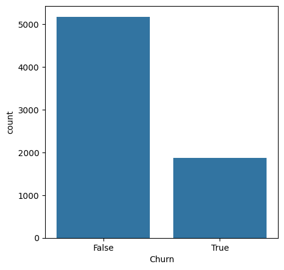

```python
import seaborn as sns

fig, ax = plt.subplots(figsize=(5, 5))

sns.countplot(data=df_merge_clean, x='Churn')
plt.show()
```

```python
df_merge_clean['Churn'].value_counts(normalize=True).round(6)*100
```

```
Churn
False    73.463
True     26.537
Name: proportion, dtype: float64
```

📊 Cómo se distribuye la evasión según variables categóricas, como **género, tipo de contrato, método de pago,** entre otras.

```python
churn_true = df_merge_clean[df_merge_clean['Churn'] == True]
churn_false = df_merge_clean[df_merge_clean['Churn'] == False]
evacion = ['gender','Contract','PaymentMethod']
evacion
```

```
['gender', 'Contract', 'PaymentMethod']
```

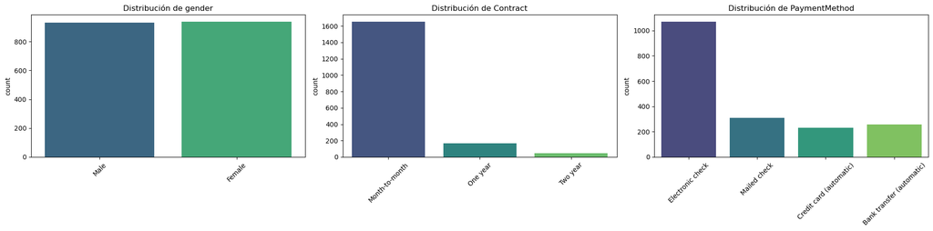

```python
fig, ax = plt.subplots(1, 3, figsize=(20, 5))

# Iteramos para crear cada barplot (count plot)
for i, col in enumerate(evacion):
    sns.countplot(data=churn_true, x=col, hue=col, ax=ax[i], palette='viridis', legend=False)
    ax[i].set_title(f'Distribución de {col}')
    ax[i].set_xlabel('')
    # Rotamos las etiquetas del eje X
    ax[i].tick_params(axis='x', rotation=45)

plt.tight_layout()
plt.show()
```

```python
for i in evacion:
    print(df_merge_clean[i].value_counts(normalize=True).round(6)*100)
```

```
gender
Male      50.4756
Female    49.5244
Name: proportion, dtype: float64
Contract
Month-to-month    55.0192
Two year          24.0664
One year          20.9144
Name: proportion, dtype: float64
PaymentMethod
Electronic check             33.5794
Mailed check                 22.8880
Bank transfer (automatic)    21.9225
Credit card (automatic)      21.6101
Name: proportion, dtype: float64
```

```python
df_merge_clean.columns
```

```
Index(['customerID', 'Churn', 'gender', 'SeniorCitizen', 'Partner',
       'Dependents', 'tenure', 'PhoneService', 'MultipleLines',
       'InternetService', 'OnlineSecurity', 'OnlineBackup', 'DeviceProtection',
       'TechSupport', 'StreamingTV', 'StreamingMovies', 'Contract',
       'PaperlessBilling', 'PaymentMethod', 'ChargesMonthly', 'ChargesTotal',
       'Cuentas_Diarias'],
      dtype='object')
```

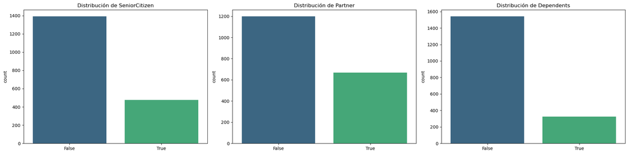

```python
analizys_familia = ['SeniorCitizen', 'Partner', 'Dependents']

fig, ax = plt.subplots(1, 3, figsize=(20, 5))

# Iteramos para crear cada barplot (count plot)
for i, col in enumerate(analizys_familia):
    sns.countplot(data=churn_true, x=col, hue=col, ax=ax[i], palette='viridis', legend=False)
    ax[i].set_title(f'Distribución de {col}')
    ax[i].set_xlabel('')

plt.tight_layout()
plt.show()
```

```python
tabla_porcentajes = df_merge_clean[['SeniorCitizen', 'Partner', 'Dependents']].apply(lambda x: x.value_counts(normalize=True))
# Multiplicamos por 100 y formateamos para que sea más legible
tabla_porcentajes = (tabla_porcentajes * 100).round(2).T
# Renombramos las columnas para que sean claras
tabla_porcentajes.columns = ['Porcentaje False (%)', 'Porcentaje True (%)']
# Mostramos la tabla
print(tabla_porcentajes)
```

```
               Porcentaje False (%)  Porcentaje True (%)
SeniorCitizen                 83.79                16.21
Partner                       51.70                48.30
Dependents                    70.04                29.96
```

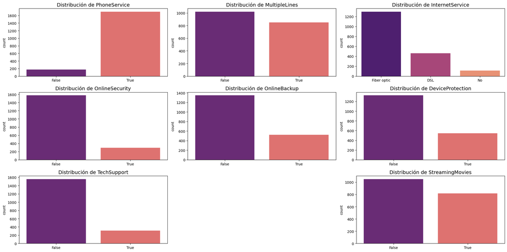

```python
analizys_servicios = ['PhoneService', 'MultipleLines', 'InternetService', 'OnlineSecurity', 'OnlineBackup', 'DeviceProtection', 'TechSupport', 'StreamingTV', 'StreamingMovies']

fig, ax = plt.subplots(3, 3, figsize=(20, 10))
axes = ax.flatten()

# Iteramos para crear cada barplot (count plot)
for i, col in enumerate(analizys_servicios):
    sns.countplot(data=churn_true, x=col, hue=col, ax=axes[i], palette='magma', legend=False)
    axes[i].set_title(f'Distribución de {col}', fontsize=14)
    axes[i].set_xlabel('')

# Eliminamos el último gráfico que queda vacío
fig.delaxes(axes[7])

plt.tight_layout()
plt.show()
```

✅ Explorar cómo las variables numéricas, como "total gastado" o "tiempo de contrato", se distribuyen entre los clientes que cancelaron (evasión) y los que no cancelaron.

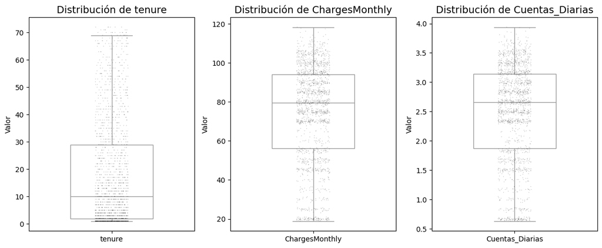

```python
analizys_boxplot = ['tenure', 'ChargesMonthly', 'Cuentas_Diarias']

fig, ax = plt.subplots(1, 3, figsize=(12, 5))
for i, col in enumerate(analizys_boxplot):
    # Usamos x=[""] * len(churn_true) para crear una base común
    # Y asignamos un nombre fijo al hue para que no se pierda en valores individuales
    sns.boxplot(
        data=churn_true,
        y=col,
        x=[col] * len(churn_true), # Esto crea una etiqueta única en el eje X
        hue=[col] * len(churn_true), # Esto asigna un color único a esa etiqueta
        ax=ax[i],
        palette='dark:white_r',
        legend=False,
        width=0.5,
        fliersize=0

    )

    # Encima dibujamos el Stripplot (los puntos individuales)
    sns.stripplot(
        data=churn_true,
        y=col,
        ax=ax[i],
        x=[col] * len(churn_true),
        hue=[col] * len(churn_true),
        size=1,        # Puntos muy pequeños
        jitter=True,   # Dispersión horizontal
        alpha=0.3,     # Transparencia
        palette='dark:black',
    )

    ax[i].set_title(f'Distribución de {col}', fontsize=14)
    ax[i].set_xlabel('') # Limpiamos el eje X para que no se vea repetido
    ax[i].set_ylabel('Valor')

plt.tight_layout()
plt.show()
```

```python
churn_true[['tenure','ChargesMonthly','Cuentas_Diarias']].describe()
```

|  | tenure | ChargesMonthly | Cuentas_Diarias |
| --- | --- | --- | --- |
| count | 1869.000000 | 1869.000000 | 1869.000000 |
| mean | 17.979133 | 74.441332 | 2.481450 |
| std | 19.531123 | 24.666053 | 0.822287 |
| min | 1.000000 | 18.850000 | 0.630000 |
| 25% | 2.000000 | 56.150000 | 1.870000 |
| 50% | 10.000000 | 79.650000 | 2.660000 |
| 75% | 29.000000 | 94.200000 | 3.140000 |
| max | 72.000000 | 118.350000 | 3.940000 |

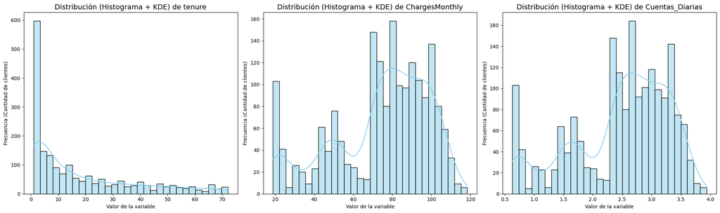

```python
fig, axes = plt.subplots(1, 3, figsize=(20, 6))

for i, col in enumerate(analizys_boxplot):
    # Usamos histplot con KDE para ver la "montaña" de densidad
    sns.histplot(data=churn_true, x=col, kde=True, ax=axes[i], color='skyblue', bins=30)

    axes[i].set_title(f'Distribución (Histograma + KDE) de {col}', fontsize=14)
    axes[i].set_ylabel('Frecuencia (Cantidad de clientes)')
    axes[i].set_xlabel('Valor de la variable')

plt.tight_layout()
plt.show()
```

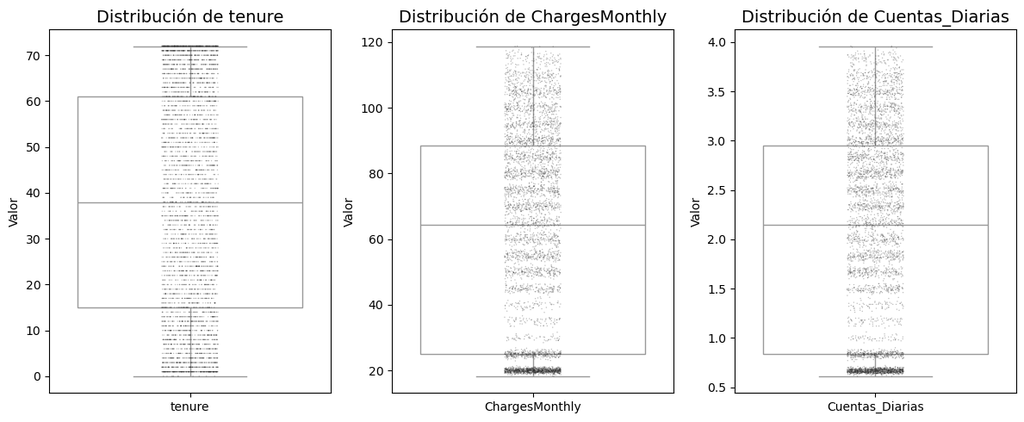

```python
analizys_boxplot = ['tenure', 'ChargesMonthly', 'Cuentas_Diarias']

fig, ax = plt.subplots(1, 3, figsize=(12, 5))
for i, col in enumerate(analizys_boxplot):
    # Usamos x=[""] * len(churn_false) para crear una base común
    # Y asignamos un nombre fijo al hue para que no se pierda en valores individuales
    sns.boxplot(
        data=churn_false,
        y=col,
        x=[col] * len(churn_false), # Esto crea una etiqueta única en el eje X
        hue=[col] * len(churn_false), # Esto asigna un color único a esa etiqueta
        ax=ax[i],
        palette='dark:white_r',
        legend=False
    )

    # Encima dibujamos el Stripplot (los puntos individuales)
    sns.stripplot(
        data=churn_false,
        y=col,
        ax=ax[i],
        x=[col] * len(churn_false),
        hue=[col] * len(churn_false),
        size=1,        # Puntos muy pequeños
        jitter=True,   # Dispersión horizontal
        alpha=0.3,     # Transparencia
        palette='dark:black',
    )

    ax[i].set_title(f'Distribución de {col}', fontsize=14)
    ax[i].set_xlabel('') # Limpiamos el eje X para que no se vea repetido
    ax[i].set_ylabel('Valor')

plt.tight_layout()
plt.show()
```

```python
churn_false[['tenure','ChargesMonthly','Cuentas_Diarias']].describe()
```

|  | tenure | ChargesMonthly | Cuentas_Diarias |
| --- | --- | --- | --- |
| count | 5174.000000 | 5174.000000 | 5174.000000 |
| mean | 37.569965 | 61.265124 | 2.042080 |
| std | 24.113777 | 31.092648 | 1.036492 |
| min | 0.000000 | 18.250000 | 0.610000 |
| 25% | 15.000000 | 25.100000 | 0.840000 |
| 50% | 38.000000 | 64.425000 | 2.150000 |
| 75% | 61.000000 | 88.400000 | 2.950000 |
| max | 72.000000 | 118.750000 | 3.960000 |

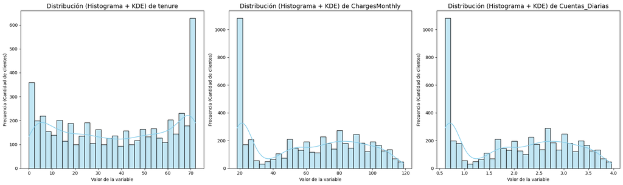

```python
fig, axes = plt.subplots(1, 3, figsize=(20, 6))

for i, col in enumerate(analizys_boxplot):
    # Usamos histplot con KDE para ver la "montaña" de densidad
    sns.histplot(data=churn_false, x=col, kde=True, ax=axes[i], color='skyblue', bins=30)

    axes[i].set_title(f'Distribución (Histograma + KDE) de {col}', fontsize=14)
    axes[i].set_ylabel('Frecuencia (Cantidad de clientes)')
    axes[i].set_xlabel('Valor de la variable')

plt.tight_layout()
plt.show()
```

# 📊 Análisis de correlación entre variables

> Explorar la correlación entre diferentes variables del dataset. Esto puede ayudar a identificar qué factores tienen mayor relación con la evasión de clientes, > como:

> 🔹 La relación entre la cuenta diaria y la evasión.

> 🔹 Cómo la cantidad de servicios contratados afecta la probabilidad de churn.

```python
# Seleccionamos solo las columnas numéricas y booleanas
corr_matrix = df_merge_clean.select_dtypes(include=['number', 'bool']).corr()
corr_matrix
```

|  | Churn | SeniorCitizen | Partner | Dependents | tenure | PhoneService | MultipleLines | OnlineSecurity | OnlineBackup | DeviceProtection | TechSupport | StreamingTV | StreamingMovies | PaperlessBilling | ChargesMonthly | ChargesTotal | Cuentas_Diarias |
| --- | --- | --- | --- | --- | --- | --- | --- | --- | --- | --- | --- | --- | --- | --- | --- | --- | --- |
| Churn | 1.000000 | 0.150889 | -0.150448 | -0.164221 | -0.352229 | 0.011942 | 0.040102 | -0.171226 | -0.082255 | -0.066160 | -0.164674 | 0.063228 | 0.061382 | 0.191825 | 0.193356 | -0.198324 | 0.193412 |
| SeniorCitizen | 0.150889 | 1.000000 | 0.016479 | -0.211185 | 0.016567 | 0.008576 | 0.142948 | -0.038653 | 0.066572 | 0.059428 | -0.060625 | 0.105378 | 0.120176 | 0.156530 | 0.220173 | 0.103006 | 0.220147 |
| Partner | -0.150448 | 0.016479 | 1.000000 | 0.452676 | 0.379697 | 0.017706 | 0.142057 | 0.143106 | 0.141498 | 0.153786 | 0.119999 | 0.124666 | 0.117412 | -0.014877 | 0.096848 | 0.317504 | 0.096909 |
| Dependents | -0.164221 | -0.211185 | 0.452676 | 1.000000 | 0.159712 | -0.001762 | -0.024526 | 0.080972 | 0.023671 | 0.013963 | 0.063268 | -0.016558 | -0.039741 | -0.111377 | -0.113890 | 0.062078 | -0.113939 |
| tenure | -0.352229 | 0.016567 | 0.379697 | 0.159712 | 1.000000 | 0.008448 | 0.331941 | 0.327203 | 0.360277 | 0.360653 | 0.324221 | 0.279756 | 0.286111 | 0.006152 | 0.247900 | 0.826178 | 0.247910 |
| PhoneService | 0.011942 | 0.008576 | 0.017706 | -0.001762 | 0.008448 | 1.000000 | 0.279690 | -0.092893 | -0.052312 | -0.071227 | -0.096340 | -0.022574 | -0.032959 | 0.016505 | 0.247398 | 0.113214 | 0.247361 |
| MultipleLines | 0.040102 | 0.142948 | 0.142057 | -0.024526 | 0.331941 | 0.279690 | 1.000000 | 0.098108 | 0.202237 | 0.201137 | 0.100571 | 0.257152 | 0.258751 | 0.163530 | 0.490434 | 0.468504 | 0.490457 |
| OnlineSecurity | -0.171226 | -0.038653 | 0.143106 | 0.080972 | 0.327203 | -0.092893 | 0.098108 | 1.000000 | 0.283832 | 0.275438 | 0.354931 | 0.176207 | 0.187398 | -0.003636 | 0.296594 | 0.411651 | 0.296591 |
| OnlineBackup | -0.082255 | 0.066572 | 0.141498 | 0.023671 | 0.360277 | -0.052312 | 0.202237 | 0.283832 | 1.000000 | 0.303546 | 0.294233 | 0.282106 | 0.274501 | 0.126735 | 0.441780 | 0.509226 | 0.441762 |
| DeviceProtection | -0.066160 | 0.059428 | 0.153786 | 0.013963 | 0.360653 | -0.071227 | 0.201137 | 0.275438 | 0.303546 | 1.000000 | 0.333313 | 0.390874 | 0.402111 | 0.103797 | 0.482692 | 0.521983 | 0.482648 |
| TechSupport | -0.164674 | -0.060625 | 0.119999 | 0.063268 | 0.324221 | -0.096340 | 0.100571 | 0.354931 | 0.294233 | 0.333313 | 1.000000 | 0.278070 | 0.279358 | 0.037880 | 0.338304 | 0.431883 | 0.338300 |
| StreamingTV | 0.063228 | 0.105378 | 0.124666 | -0.016558 | 0.279756 | -0.022574 | 0.257152 | 0.176207 | 0.282106 | 0.390874 | 0.278070 | 1.000000 | 0.533094 | 0.223841 | 0.629603 | 0.514973 | 0.629604 |
| StreamingMovies | 0.061382 | 0.120176 | 0.117412 | -0.039741 | 0.286111 | -0.032959 | 0.258751 | 0.187398 | 0.274501 | 0.402111 | 0.279358 | 0.533094 | 1.000000 | 0.211716 | 0.627429 | 0.520122 | 0.627402 |
| PaperlessBilling | 0.191825 | 0.156530 | -0.014877 | -0.111377 | 0.006152 | 0.016505 | 0.163530 | -0.003636 | 0.126735 | 0.103797 | 0.037880 | 0.223841 | 0.211716 | 1.000000 | 0.352150 | 0.158574 | 0.352135 |
| ChargesMonthly | 0.193356 | 0.220173 | 0.096848 | -0.113890 | 0.247900 | 0.247398 | 0.490434 | 0.296594 | 0.441780 | 0.482692 | 0.338304 | 0.629603 | 0.627429 | 0.352150 | 1.000000 | 0.651174 | 0.999996 |
| ChargesTotal | -0.198324 | 0.103006 | 0.317504 | 0.062078 | 0.826178 | 0.113214 | 0.468504 | 0.411651 | 0.509226 | 0.521983 | 0.431883 | 0.514973 | 0.520122 | 0.158574 | 0.651174 | 1.000000 | 0.651189 |
| Cuentas_Diarias | 0.193412 | 0.220147 | 0.096909 | -0.113939 | 0.247910 | 0.247361 | 0.490457 | 0.296591 | 0.441762 | 0.482648 | 0.338300 | 0.629604 | 0.627402 | 0.352135 | 0.999996 | 0.651189 | 1.000000 |

### 📊 Matriz de Correlacion

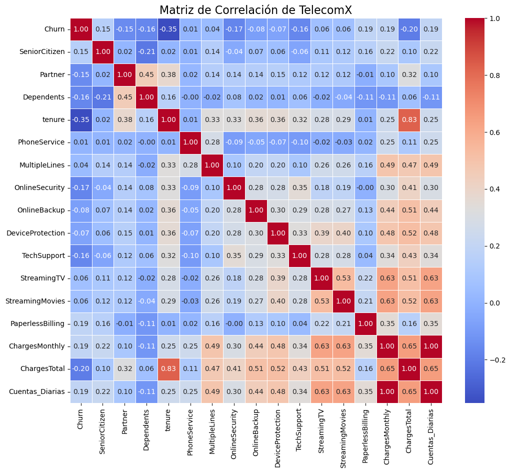

```python
plt.figure(figsize=(12, 10))
sns.heatmap(corr_matrix, annot=True, cmap='coolwarm', fmt=".2f", linewidths=0.5)

plt.title('Matriz de Correlación de TelecomX', fontsize=16)
plt.show()
```

### 📊 Correlacion directa con la evacion.

```python
# Ordenamos de mayor a menor para que el gráfico sea legible y dejaamos solo la correlacion con Churn.
churn_corr = corr_matrix['Churn'].sort_values(ascending=False).drop('Churn').reset_index()
churn_corr.sample(5)
```

|  | index | Churn |
| --- | --- | --- |
| 6 | MultipleLines | 0.040102 |
| 5 | StreamingMovies | 0.061382 |
| 8 | DeviceProtection | -0.066160 |
| 10 | Partner | -0.150448 |
| 14 | ChargesTotal | -0.198324 |

```python
# Renombramos las columnas
churn_corr.columns = ['Variable', 'Correlacion']
churn_corr.sample(5)
```

|  | Variable | Correlacion |
| --- | --- | --- |
| 11 | Dependents | -0.164221 |
| 9 | OnlineBackup | -0.082255 |
| 15 | tenure | -0.352229 |
| 6 | MultipleLines | 0.040102 |
| 13 | OnlineSecurity | -0.171226 |

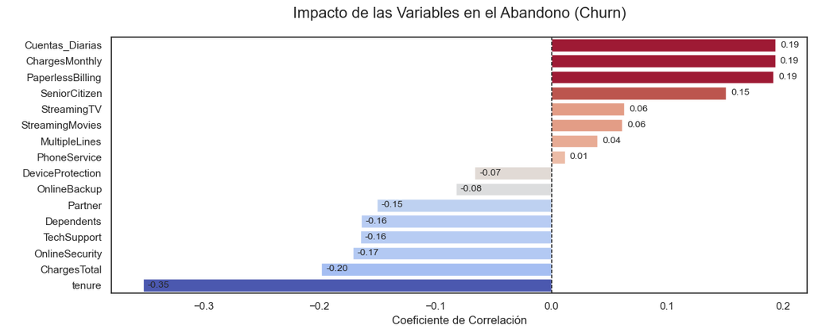

```python
sns.set_theme(style='white')

plt.figure(figsize=(12, 5))

ax = sns.barplot(
    data=churn_corr,
    x='Correlacion',
    y='Variable',
    hue='Correlacion',
    palette='coolwarm',
    legend=False
)

plt.title('Impacto de las Variables en el Abandono (Churn)', fontsize=16, pad=20)
plt.xlabel('Coeficiente de Correlación', fontsize=12)
plt.ylabel(' ')

# Añadimos una línea vertical en 0 para separar claramente los bandos
plt.axvline(0, color='black', lw=1, ls='--')

# Añadimos el valor numérico al final de cada barra
for i, p in enumerate(ax.patches):
    ax.annotate(f'{p.get_width():.2f}', (p.get_width(), p.get_y() + p.get_height()/2),
                ha='left', va='center', xytext=(5, 0),
                textcoords='offset points', fontsize=10)

plt.tight_layout()
plt.show()
```

# 📄Informe final

## Informe Técnico: Análisis de Evasión de Clientes (Churn) - TelecomX

### 1. Introducción.

El objetivo de este análisis es identificar los factores críticos que influyen en la pérdida de clientes **(Churn)** de la compañía **TelecomX**. La evasión de clientes es un desafío estratégico; retener a un usuario existente es significativamente más rentable que adquirir uno nuevo. A través de este estudio, buscamos patrones en el comportamiento de facturación, servicios contratados y antigüedad para proponer estrategias de retención basadas en datos.

### 2. Limpieza y Tratamiento de Datos

Para garantizar la integridad del análisis, se realizaron los siguientes pasos de pre-procesamiento:

- Importación Estable: Se utilizó la librería requests para descargar el dataset desde un repositorio remoto de GitHub, evitando errores de conexión incompleta (IncompleteRead).

  ```
  response = requests.get(url)
  content = response.content
  df = pd.read_json(io.StringIO(content.decode('utf-8')))
  df
  ```

- Normalización JSON: Se normaliza el documento .json con el fin de generar una base de datos tratable para realizar el analisis de acuerdo a lo solicitado.

  ```
  df_merge = columnas_01
  for i in columnas_02:
      column = pd.json_normalize(columnas_02[i])
      df_merge = pd.concat([df_merge, column], axis=1)
  df_merge.info()
  ```

    ```
    df_merge_clean = df_merge[df_merge['Churn'] != ''].copy()
    df_merge_clean.sample(5)
    ```

- Ingeniería de Características: Se creó la métrica Cuentas_Diarias, calculada como Charges.Monthly / 30, para analizar la facturación a un nivel de granularidad más detallado.

  ```
  df_merge_clean['Cuentas_Diarias'] = (df_merge_clean['ChargesMonthly']/30).round(2)
  df_merge_clean
  ```

### 3. Análisis Exploratorio de Datos (EDA)

#### 📊 Distribución y Densidad

- El 26.53% de los usuarios ya no cuentan los nuestros servicios de acuerdo a la informacion generada, `(df_merge_clean[df_merge_clean['Churn'] == True])`
- La evacion generada distribuida segun categorias como Genero, Tipo de contrato y metodo de pago, `(evacion = ['gender','Contract','PaymentMethod'])`, muestra que:
  - El genero del evasor no tiene ningun tipo de peso.

    ```
    gender
    Male      50.4756
    Female    49.5244
    ```

  - Los usuarios que mas se retiran de los servicios son quienes el tipo de contratacion es pago mes a mes.

    ```
    Contract
    Month-to-month    55.0192
    Two year          24.0664
    One year          20.9144
    ```

  - El tipo de pago mas usado por quienes se retiran del servicio es, Validacion Electronica.

    ```
    PaymentMethod
    Electronic check             33.5794
    Mailed check                 22.8880
    Bank transfer (automatic)    21.9225
    Credit card (automatic)      21.6101
    ```

- El analisis realizado sobre datos familiares personales como si el ciente es un cliente de la tercera de edad, si se encuentra o no casado o si tiene o no personas que dependen de el, `['SeniorCitizen', 'Partner', 'Dependents']`, muestran que estos datos no son relevantes, pues en su mayoria la respuesta fue negativa.

  ```
                  Porcentaje False (%)  Porcentaje True (%)
  SeniorCitizen                 83.79                16.21
  Partner                       51.70                48.30
  Dependents                    70.04                29.96
  ```

  Utilizamos Histogramas con estimación de densidad de kernel (KDE) para entender la distribución de los clientes que no se retiran:
- Se detectó una acumulación masiva de clientes en el rango de los 20 USD (Cargos Mensuales), lo que indica un segmento dominante de usuarios con planes básicos.

[figure not shown]

- Antigüedad (Tenure): La distribución es bimodal, concentrándose en clientes muy nuevos y clientes de larga trayectoria.

Y validamos esta informacion comparandola con los clientes que se retiran y observamos:

- Los clientes que se retrian son clientes que en su mayoria no duran mas de 30 meses de contrato.

[figure not shown]

#### 📉 Análisis de Correlación

Implementamos una Matriz de Correlación con Seaborn (utilizando la paleta coolwarm) para medir el impacto de cada variable en el Churn:

[figure not shown]

- Correlación Positiva: Los cargos mensuales elevados están directamente relacionados con una mayor probabilidad de abandono.
- Correlación Negativa: La antigüedad (tenure) es el principal factor de retención; a mayor tiempo con la empresa, menor es el riesgo de evasión.

### 4. Conclusiones e Insights

- Sensibilidad al Precio: Los clientes con cargos mensuales altos presentan un riesgo de fuga significativamente mayor. El pico de usuarios en los 20 USD sugiere que la estabilidad del negocio reside en los planes de entrada.
- El Factor Lealtad: Los primeros meses de contrato son críticos. Una vez que el cliente supera la barrera inicial de antigüedad, la probabilidad de Churn cae drásticamente.
- Métricas Diarias: La nueva métrica Cuentas_Diarias permitió validar que no existen anomalías o outliers extremos que distorsionen los promedios de cobro.

### 5. Recomendaciones Estratégicas

1. Programas de Fidelización Temprana: Implementar incentivos o descuentos durante los primeros 6 meses de contrato para reducir el Churn en clientes nuevos.
2. Alertas por Cargos Elevados: Monitorear a los clientes cuyos cargos mensuales superen el promedio del segmento (aprox. 65 USD) y ofrecerles planes empaquetados más competitivos.
3. Migración de Métodos de Pago: Fomentar el uso de tarjetas de crédito o transferencias automáticas, ya que suelen estar asociados a una menor tasa de olvido o deserción.